# Utilities Dataset t Test

May 22, 2018

## Background

As I began to look at the data we were given on utilities, I was curious what fields would be interesting to compare in a t-test and *what* type of t test as well. I decided to do an **independent t-test** I knew that it would be important to compare on fields with similar units, so I wondered **Is there a difference in the mean of the gas bills to the electric bill?** Stated in notation:

$$H_0: \mu_\text{gas} = \mu_\text{electric}$$
$$H_a: \mu_\text{gas} \neq \mu_\text{electric}$$
Essentially, is the average bill for gas the same as the average bill for electric? Initially, I assumed that this relationship would not be equal to each other. On the surface, electricity is [*typically*](https://www.ovoenergy.com/guides/energy-guides/the-average-gas-bill-average-electricity-bill-compared.html) cheaper[^1] than gas per unit (i.e., per kWh), so I thought that naturally, the data would show that the averages are not the same. Well, lets dig in to some analysis and find out!

## Analysis

I decided to create a box plot and then conduct a `t test` with the two variables `gasbill` (Gas Bill in $) and `elecbill` (Electric Bill in $). I wanted to see if there was a difference in the average price between the two groups. I wanted to see, using a box plot, what the spread of the data was. Lets take a quick look at those plots.

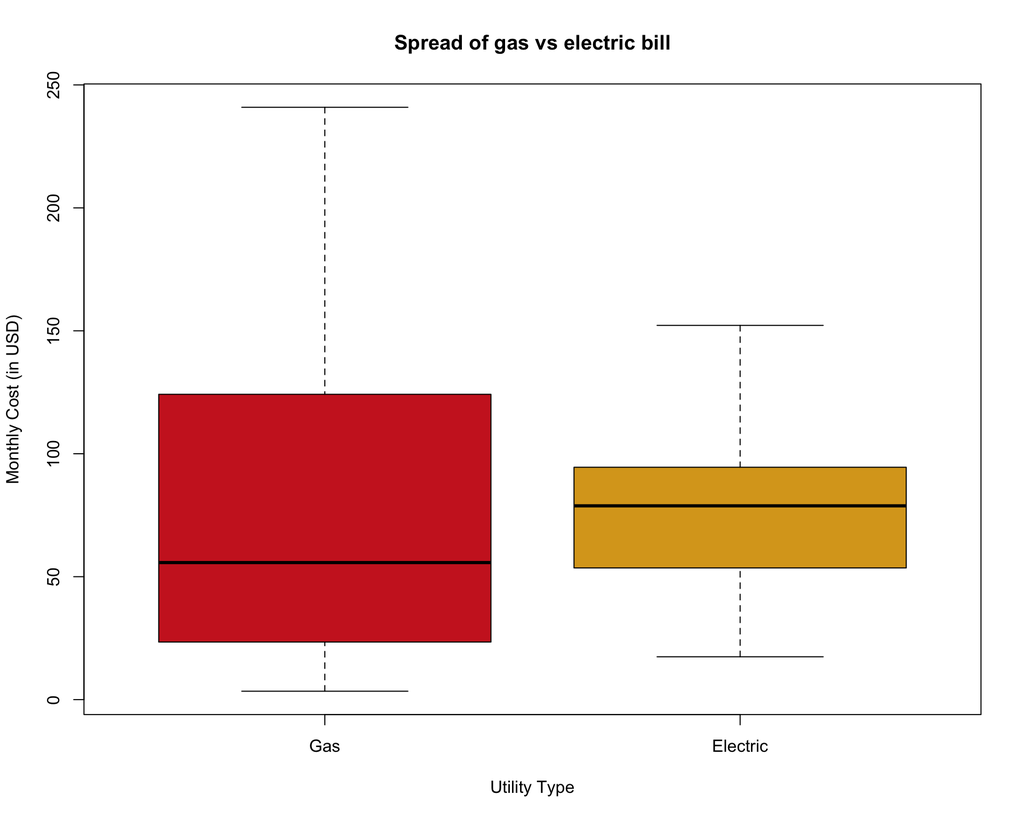

```r
boxplot(Utilities$gasbill, Utilities$elecbill, names = c("Gas", "Electric"), col = c("firebrick3", "goldenrod"),
        main = "Spread of gas vs electric bill",
        xlab = "Utility Type",
        ylab = "Monthly Cost (in USD)")
```

```r
par(mfrow=c(1,2))
qqPlot(Utilities$gasbill, distribution = "norm", xlab = "Quantiles", ylab = "Gas bill ($)", main = "Q-Q Plot (Gas)", col = "firebrick3", col.lines = "black")
```

```
## [1]  65 101
```

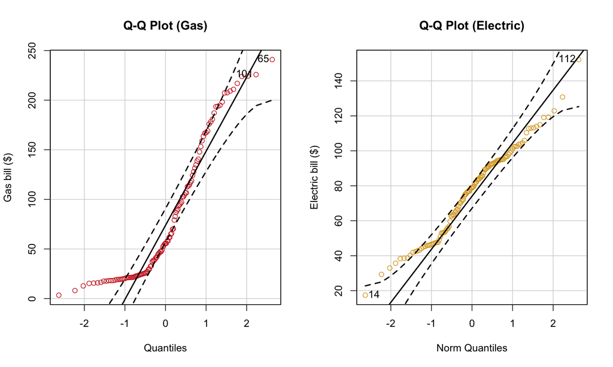

```
## [1] 112  14
```

```r
qqPlot(Utilities$elecbill, distribution = "norm", xlab = "Norm Quantiles", ylab = "Electric bill ($)", main = "Q-Q Plot (Electric)", col = "goldenrod", col.lines = "black")
```

Looking at the QQ plots, we can see that the data is **not normal**. This will affect the results of the test, but we will continue with the test.

To perform my test, I compared my `gasbill` to `elecbill` and performed the test. Since our sample had more than fifteen observations, we can perform a t test. Take a look below.

```r
pander((t.test(Utilities$gasbill, Utilities$elecbill, mu = 0, alternative = "two.sided", conf.level = 0.95)), caption = "Two Sample t-test: `Gas Bill` and `Electric Bill`")
```

Two Sample t-test: `Gas Bill` and `Electric Bill`

| Test statistic | df | P value | Alternative hypothesis | mean of x | mean of y |
| --- | --- | --- | --- | --- | --- |
| 0.6951 | 149 | 0.4881 | two.sided | 81.24 | 76.67 |

## Interpretation

Home

[^1]: https://www.ovoenergy.com/guides/energy-guides/the-average-gas-bill-average-electricity-bill-compared.html